# MW Mock Python Student Facing Questions

### Python Screening test

```python
import pandas as pd
import numpy as np
import matplotlib as mpl
import matplotlib.pyplot as plt
dataframe = pd.read_csv("adult_census_data.csv")
```

```python
print(dataframe.head(3))
```

```
   39          State-gov   77516   Bachelors   13        Never-married  \
0  50   Self-emp-not-inc   83311   Bachelors   13   Married-civ-spouse
1  38            Private  215646     HS-grad    9             Divorced
2  53            Private  234721        11th    7   Married-civ-spouse

         Adm-clerical   Not-in-family   White   Male   2174   0   40  \
0     Exec-managerial         Husband   White   Male      0   0   13
1   Handlers-cleaners   Not-in-family   White   Male      0   0   40
2   Handlers-cleaners         Husband   Black   Male      0   0   40

    United-States   <=50K
0   United-States   <=50K
1   United-States   <=50K
2   United-States   <=50K
```

```python
print(dataframe.columns)
```

```
Index(['39', ' State-gov', ' 77516', ' Bachelors', ' 13', ' Never-married',
       ' Adm-clerical', ' Not-in-family', ' White', ' Male', ' 2174', ' 0',
       ' 40', ' United-States', ' <=50K'],
      dtype='object')
```

**Q1. After importing the adult_census_data.csv file, please filter this to include only the following criteria:**

State-Gov

Bachelors

Never-Married

Adm-Clerical

Not-in-familiy

White

Male

United States

<=50K

**Feel free to any method to complete this tasks. However, we recommend you use either list filtering [], or .loc to complete this task.**

**Put your code below**

```python
df= dataframe.select_dtypes(['object'])
print(df.head(3))
```

```
           State-gov   Bachelors        Never-married        Adm-clerical  \
0   Self-emp-not-inc   Bachelors   Married-civ-spouse     Exec-managerial
1            Private     HS-grad             Divorced   Handlers-cleaners
2            Private        11th   Married-civ-spouse   Handlers-cleaners

    Not-in-family   White   Male   United-States   <=50K
0         Husband   White   Male   United-States   <=50K
1   Not-in-family   White   Male   United-States   <=50K
2         Husband   Black   Male   United-States   <=50K
```

```python
df1=dataframe[[' State-gov', ' Bachelors', ' Never-married', ' Adm-clerical', ' Not-in-family', ' White', ' Male', ' United-States', ' <=50K']]
```

```python
print(df1.head(4))
```

```
           State-gov   Bachelors        Never-married        Adm-clerical  \
0   Self-emp-not-inc   Bachelors   Married-civ-spouse     Exec-managerial
1            Private     HS-grad             Divorced   Handlers-cleaners
2            Private        11th   Married-civ-spouse   Handlers-cleaners
3            Private   Bachelors   Married-civ-spouse      Prof-specialty

    Not-in-family   White     Male   United-States   <=50K
0         Husband   White     Male   United-States   <=50K
1   Not-in-family   White     Male   United-States   <=50K
2         Husband   Black     Male   United-States   <=50K
3            Wife   Black   Female            Cuba   <=50K
```

**Currently, the dataframe you are using has the following column names:**

[' State-gov', ' Bachelors', ' Never-married', ' Adm-clerical', ' Not-in-family', ' White', ' Male', ' United-States', ' <=50K']

**Q2. Please re-name all the newly filtered columns in the pandas DataFrame to the following:**

Employment Type, Degree Status, Marriage-Status, Job-Role, Family-Role, Ethnicity, Gender, Country, Earnings

E.g. State-Gov becomes Employment Type, Bachelors becomes Degree Status, etc.

**Put your code below**

```python
df2=df.rename(columns={' State-gov':'Employment Type', ' Bachelors':'Degree Status', ' Never-married':'Marriage-Status', ' Adm-clerical':'Job-Role', ' Not-in-family':'Family-Role', ' White':'Ethnicity', ' Male':'Gender', ' United-States':'Country', ' <=50K':'Earnings'})
```

```python
print(df2)
```

```
         Employment Type Degree Status      Marriage-Status  \
0       Self-emp-not-inc     Bachelors   Married-civ-spouse
1                Private       HS-grad             Divorced
2                Private          11th   Married-civ-spouse
3                Private     Bachelors   Married-civ-spouse
4                Private       Masters   Married-civ-spouse
...                  ...           ...                  ...
32555            Private    Assoc-acdm   Married-civ-spouse
32556            Private       HS-grad   Married-civ-spouse
32557            Private       HS-grad              Widowed
32558            Private       HS-grad        Never-married
32559       Self-emp-inc       HS-grad   Married-civ-spouse

                 Job-Role     Family-Role Ethnicity   Gender         Country  \
0         Exec-managerial         Husband     White     Male   United-States
```

[output cut: 25 more lines]

**Q3. The Job Role Columns holds the job information for each individual in this census snapshot. Using this column, create a Bar Chart that shows the count of 'Unique' Jobs per Job Group in the "Job-Role" Column in ascending order, as per the provided image below**

```python
print(df2.info())
print(df2.head(4))
```

```
<class 'pandas.core.frame.DataFrame'>
RangeIndex: 32560 entries, 0 to 32559
Data columns (total 9 columns):
 #   Column           Non-Null Count  Dtype
---  ------           --------------  -----
 0   Employment Type  32560 non-null  object
 1   Degree Status    32560 non-null  object
 2   Marriage-Status  32560 non-null  object
 3   Job-Role         32560 non-null  object
 4   Family-Role      32560 non-null  object
 5   Ethnicity        32560 non-null  object
 6   Gender           32560 non-null  object
 7   Country          32560 non-null  object
 8   Earnings         32560 non-null  object
dtypes: object(9)
memory usage: 2.2+ MB
None
     Employment Type Degree Status      Marriage-Status            Job-Role  \
0   Self-emp-not-inc     Bachelors   Married-civ-spouse     Exec-managerial
1            Private       HS-grad             Divorced   Handlers-cleaners
2            Private          11th   Married-civ-spouse   Handlers-cleaners
3            Private     Bachelors   Married-civ-spouse      Prof-specialty

      Family-Role Ethnicity   Gender         Country Earnings
0         Husband     White     Male   United-States    <=50K
1   Not-in-family     White     Male   United-States    <=50K
2         Husband     Black     Male   United-States    <=50K
3            Wife     Black   Female            Cuba    <=50K
```

```python
job_counted = pd.value_counts(df2['Job-Role'])
```

```python
print(job_counted)
```

```
 Prof-specialty       4140
 Craft-repair         4099
 Exec-managerial      4066
 Adm-clerical         3769
 Sales                3650
 Other-service        3295
 Machine-op-inspct    2002
 ?                    1843
 Transport-moving     1597
 Handlers-cleaners    1370
 Farming-fishing       994
 Tech-support          928
 Protective-serv       649
 Priv-house-serv       149
 Armed-Forces            9
Name: Job-Role, dtype: int64
```

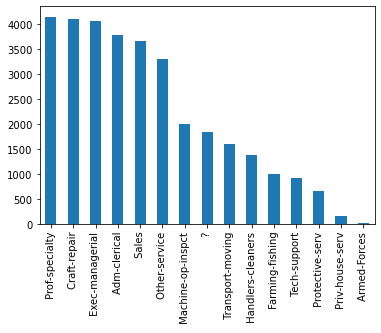

```python
job_counted.plot(kind='bar')
```

**Put your code below**

**Q4. Please create two bar plots as per below that show:**

```
1) The number of individuals who have a High School Graduate Diploma AND earn <=50K in the United States
2) The number of individuals who have a High School Graduate Diploma AND earn >50K in the United States
```

Please note you will be looking specifically at the *Job Role* column

```python
print(df2.head())
```

```
     Employment Type Degree Status      Marriage-Status            Job-Role  \
0   Self-emp-not-inc     Bachelors   Married-civ-spouse     Exec-managerial
1            Private       HS-grad             Divorced   Handlers-cleaners
2            Private          11th   Married-civ-spouse   Handlers-cleaners
3            Private     Bachelors   Married-civ-spouse      Prof-specialty
4            Private       Masters   Married-civ-spouse     Exec-managerial

      Family-Role Ethnicity   Gender         Country Earnings
0         Husband     White     Male   United-States    <=50K
1   Not-in-family     White     Male   United-States    <=50K
2         Husband     Black     Male   United-States    <=50K
3            Wife     Black   Female            Cuba    <=50K
4            Wife     White   Female   United-States    <=50K
```

```python
print(df2['Degree Status'].unique())
```

```
[' Bachelors' ' HS-grad' ' 11th' ' Masters' ' 9th' ' Some-college'
 ' Assoc-acdm' ' Assoc-voc' ' 7th-8th' ' Doctorate' ' Prof-school'
 ' 5th-6th' ' 10th' ' 1st-4th' ' Preschool' ' 12th']
```

```python
print(df2.Country.unique())
```

```
[' United-States' ' Cuba' ' Jamaica' ' India' ' ?' ' Mexico' ' South'
 ' Puerto-Rico' ' Honduras' ' England' ' Canada' ' Germany' ' Iran'
 ' Philippines' ' Italy' ' Poland' ' Columbia' ' Cambodia' ' Thailand'
 ' Ecuador' ' Laos' ' Taiwan' ' Haiti' ' Portugal' ' Dominican-Republic'
 ' El-Salvador' ' France' ' Guatemala' ' China' ' Japan' ' Yugoslavia'
 ' Peru' ' Outlying-US(Guam-USVI-etc)' ' Scotland' ' Trinadad&Tobago'
 ' Greece' ' Nicaragua' ' Vietnam' ' Hong' ' Ireland' ' Hungary'
 ' Holand-Netherlands']
```

```python
print(df2.Earnings.unique())
```

```
[' <=50K' ' >50K']
```

```python
df2.Country = df2.Country.str.strip()
```

```python
df2.Earnings = df2.Earnings.str.strip()
```

```python
df2['Degree Status'] = df2['Degree Status'].str.strip()
```

```python
print(df2['Degree Status'].unique())
print(df2.Country.unique())
print(df2.Earnings.unique())
```

```
['Bachelors' 'HS-grad' '11th' 'Masters' '9th' 'Some-college' 'Assoc-acdm'
 'Assoc-voc' '7th-8th' 'Doctorate' 'Prof-school' '5th-6th' '10th'
 '1st-4th' 'Preschool' '12th']
['United-States' 'Cuba' 'Jamaica' 'India' '?' 'Mexico' 'South'
 'Puerto-Rico' 'Honduras' 'England' 'Canada' 'Germany' 'Iran'
 'Philippines' 'Italy' 'Poland' 'Columbia' 'Cambodia' 'Thailand' 'Ecuador'
 'Laos' 'Taiwan' 'Haiti' 'Portugal' 'Dominican-Republic' 'El-Salvador'
 'France' 'Guatemala' 'China' 'Japan' 'Yugoslavia' 'Peru'
 'Outlying-US(Guam-USVI-etc)' 'Scotland' 'Trinadad&Tobago' 'Greece'
 'Nicaragua' 'Vietnam' 'Hong' 'Ireland' 'Hungary' 'Holand-Netherlands']
['<=50K' '>50K']
```

```python
hs_low = df2[(df2['Degree Status']=='HS-grad') & (df2['Country']=='United-States') & (df2['Earnings']=='<=50K')]
```

```python
hs_low
```

|  | Employment Type | Degree Status | Marriage-Status | Job-Role | Family-Role | Ethnicity | Gender | Country | Earnings |
| --- | --- | --- | --- | --- | --- | --- | --- | --- | --- |
| 1 | Private | HS-grad | Divorced | Handlers-cleaners | Not-in-family | White | Male | United-States | <=50K |
| 15 | Self-emp-not-inc | HS-grad | Never-married | Farming-fishing | Own-child | White | Male | United-States | <=50K |
| 16 | Private | HS-grad | Never-married | Machine-op-inspct | Unmarried | White | Male | United-States | <=50K |
| 20 | Private | HS-grad | Separated | Other-service | Unmarried | Black | Female | United-States | <=50K |
| 23 | Private | HS-grad | Divorced | Tech-support | Unmarried | White | Female | United-States | <=50K |
| ... | ... | ... | ... | ... | ... | ... | ... | ... | ... |
| 32539 | State-gov | HS-grad | Separated | Adm-clerical | Own-child | White | Female | United-States | <=50K |
| 32540 | ? | HS-grad | Separated | ? | Not-in-family | Black | Female | United-States | <=50K |
| 32541 | ? | HS-grad | Married-civ-spouse | ? | Husband | White | Male | United-States | <=50K |
| 32557 | Private | HS-grad | Widowed | Adm-clerical | Unmarried | White | Female | United-States | <=50K |
| 32558 | Private | HS-grad | Never-married | Adm-clerical | Own-child | White | Male | United-States | <=50K |

8119 rows × 9 columns

```python
print(hs_low)
```

```
         Employment Type Degree Status      Marriage-Status  \
1                Private       HS-grad             Divorced
15      Self-emp-not-inc       HS-grad        Never-married
16               Private       HS-grad        Never-married
20               Private       HS-grad            Separated
23               Private       HS-grad             Divorced
...                  ...           ...                  ...
32539          State-gov       HS-grad            Separated
32540                  ?       HS-grad            Separated
32541                  ?       HS-grad   Married-civ-spouse
32557            Private       HS-grad              Widowed
32558            Private       HS-grad        Never-married

                 Job-Role     Family-Role Ethnicity   Gender        Country  \
1       Handlers-cleaners   Not-in-family     White     Male  United-States
```

[output cut: 25 more lines]

```python
hs_low_count=hs_low['Job-Role'].value_counts()
```

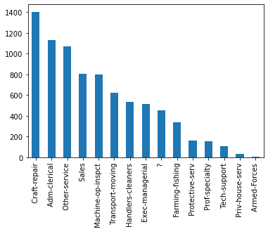

```python
hs_low_count.plot(kind='bar')
```

```python
hs_high = df2[(df2['Degree Status']=='HS-grad') & (df2['Country']=='United-States') & (df2['Earnings']=='>50K')]
```

```python
print(hs_high)
```

```
         Employment Type Degree Status      Marriage-Status  \
6       Self-emp-not-inc       HS-grad   Married-civ-spouse
66               Private       HS-grad   Married-civ-spouse
83               Private       HS-grad             Divorced
85             Local-gov       HS-grad   Married-civ-spouse
104         Self-emp-inc       HS-grad   Married-civ-spouse
...                  ...           ...                  ...
32414   Self-emp-not-inc       HS-grad   Married-civ-spouse
32461       Self-emp-inc       HS-grad   Married-civ-spouse
32517          Local-gov       HS-grad   Married-civ-spouse
32556            Private       HS-grad   Married-civ-spouse
32559       Self-emp-inc       HS-grad   Married-civ-spouse

                 Job-Role     Family-Role Ethnicity   Gender        Country  \
6         Exec-managerial         Husband     White     Male  United-States
```

[output cut: 25 more lines]

```python
hs_high_count=hs_high['Job-Role'].value_counts()
```

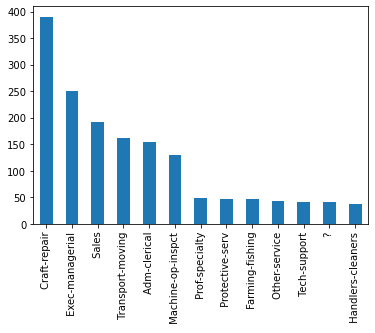

```python
hs_high_count.plot(kind='bar')
```

**Put Your Code Below**

## Challenge Question

**Q5. Which Job Role has the highest *proportion* of individuals who earn >50K?**

**Put your code below**

```python
high_earners = df2[(df2['Earnings']=='>50K')]
```

```python
high_earners_count=high_earners['Job-Role'].value_counts(normalize=True)
```

```python
print(high_earners_count)
```

```
 Exec-managerial      0.250988
 Prof-specialty       0.237087
 Sales                0.125367
 Craft-repair         0.118480
 Adm-clerical         0.064660
 Transport-moving     0.040811
 Tech-support         0.036092
 Machine-op-inspct    0.031884
 Protective-serv      0.026910
 ?                    0.024359
 Other-service        0.017472
 Farming-fishing      0.014666
 Handlers-cleaners    0.010968
 Armed-Forces         0.000128
 Priv-house-serv      0.000128
Name: Job-Role, dtype: float64
```